# Lab Session 9b

Lidia Montero, Josep Anton Sanchez & Jordi Cortes

November 2018

# SHIPS data (exemple McCullagh):

### Data

*type*: tipus de vaixell (A;B;C;D;E)

*construction*: any de construccio (1960-64;1965-69;1974-79;1960-64;)

*operation*: periode d’activitat (1960-74;1975-79)

*service*: mesos de servei

*incidents*: nombre d’incidencies

# Inicialització

### Carregar paquets i dades ShipAccidents del paquet AER

```r
options(warn = -1)
library(MASS,warn.conflicts = FALSE,quietly = TRUE)   # glm.nb
library(car,warn.conflicts = FALSE,quietly = TRUE)    # ShipAccidents; Anova
library(AER,warn.conflicts = FALSE,quietly = TRUE)    # dispersion.test
library(effects,warn.conflicts = FALSE,quietly = TRUE)# allEffects

data(ShipAccidents)                                   # data in package AER
df <- subset(ShipAccidents , service > 0)
```

**Sol: Construim una submostra amb aquells que han estat de servei**

### Descriptiva

```r
summary(df)
```

```
##  type   construction   operation     service        incidents
##  A:7   1960-64: 8    1960-74:14   Min.   :   45   Min.   : 0.00
##  B:7   1965-69:10    1975-79:20   1st Qu.:  371   1st Qu.: 1.00
##  C:7   1970-74:10                 Median : 1095   Median : 4.00
##  D:7   1975-79: 6                 Mean   : 4811   Mean   :10.47
##  E:6                              3rd Qu.: 2223   3rd Qu.:11.75
##                                   Max.   :44882   Max.   :58.00
```

# Poisson

### Model nul

```r
m0 <- glm(incidents ~ 1, family = poisson,  data = df, offset = log(service)) # model nul
m0 <- glm(incidents ~ offset(log(service)), family = poisson,  data = df)     # model nul equivalent
summary(m0)
```

```
##
## Call:
## glm(formula = incidents ~ offset(log(service)), family = poisson,
##     data = df)
##
## Deviance Residuals:
##     Min       1Q   Median       3Q      Max
## -6.7636  -0.8573  -0.1795   1.3670   3.9808
##
## Coefficients:
##             Estimate Std. Error z value Pr(>|z|)
## (Intercept)   -6.130      0.053  -115.7   <2e-16 ***
## ---
## Signif. codes:  0 '***' 0.001 '**' 0.01 '*' 0.05 '.' 0.1 ' ' 1
##
## (Dispersion parameter for poisson family taken to be 1)
##
##     Null deviance: 146.33  on 33  degrees of freedom
## Residual deviance: 146.33  on 33  degrees of freedom
## AIC: 246.19
##
## Number of Fisher Scoring iterations: 5
```

```r
qchisq(0.95,m0$df.res)
```

```
## [1] 47.39988
```

Deviança residual 146.33 amb 33 graus de llibertat. Encara queda molt per explicar.

Estem suposant que la taxa d’incidents es la mateixa per a tots, independemtent dels factors, i com la deviança és molt gran, veiem que això és erroni.

qchisq(0.95,m0$df.res), deviança residual màcima que podriem considerar amb 33 graus de llibertat. Veiem que la deviana residual està per sobre de 47.4 i per tant el model no és bó.

### Models amb 1 variable

```r
m1a <- glm(incidents ~ type, family = poisson,  data = df, offset = log(service))
summary(m1a)
```

```
##
## Call:
## glm(formula = incidents ~ type, family = poisson, data = df,
##     offset = log(service))
##
## Deviance Residuals:
##     Min       1Q   Median       3Q      Max
## -5.3041  -0.9926  -0.4034   0.7209   3.6616
##
## Coefficients:
##             Estimate Std. Error z value Pr(>|z|)
## (Intercept)  -5.4202     0.1543 -35.127  < 2e-16 ***
## typeB        -0.8837     0.1666  -5.304 1.13e-07 ***
## typeC        -0.8260     0.3273  -2.524   0.0116 *
## typeD        -0.1459     0.2875  -0.507   0.6118
## typeE         0.3429     0.2346   1.461   0.1439
## ---
## Signif. codes:  0 '***' 0.001 '**' 0.01 '*' 0.05 '.' 0.1 ' ' 1
##
## (Dispersion parameter for poisson family taken to be 1)
##
##     Null deviance: 146.328  on 33  degrees of freedom
## Residual deviance:  90.889  on 29  degrees of freedom
## AIC: 198.76
##
## Number of Fisher Scoring iterations: 5
```

```r
cat('Punt critic per la devianza:',qchisq(0.95,m1a$df.res),'\n')
```

```
## Punt critic per la devianza: 42.55697
```

```r
m1c <- glm(incidents ~ construction, family = poisson,  data = df, offset = log(service))
summary(m1c)
```

```
##
## Call:
## glm(formula = incidents ~ construction, family = poisson, data = df,
##     offset = log(service))
##
## Deviance Residuals:
##     Min       1Q   Median       3Q      Max
## -2.9924  -0.6917  -0.3151   0.7141   3.7998
##
## Coefficients:
##                     Estimate Std. Error z value Pr(>|z|)
## (Intercept)          -6.8234     0.1195 -57.088  < 2e-16 ***
## construction1965-69   0.8108     0.1477   5.491 3.99e-08 ***
## construction1970-74   1.2009     0.1509   7.960 1.72e-15 ***
## construction1975-79   0.9636     0.2070   4.654 3.25e-06 ***
## ---
## Signif. codes:  0 '***' 0.001 '**' 0.01 '*' 0.05 '.' 0.1 ' ' 1
##
## (Dispersion parameter for poisson family taken to be 1)
##
##     Null deviance: 146.328  on 33  degrees of freedom
## Residual deviance:  73.384  on 30  degrees of freedom
## AIC: 179.25
##
## Number of Fisher Scoring iterations: 4
```

```r
cat('Punt critic per la devianza:',qchisq(0.95,m1c$df.res),'\n')
```

```
## Punt critic per la devianza: 43.77297
```

```r
m1d <- glm(incidents ~ operation, family = poisson,  data = df, offset = log(service))
summary(m1d)
```

```
##
## Call:
## glm(formula = incidents ~ operation, family = poisson, data = df,
##     offset = log(service))
##
## Deviance Residuals:
##     Min       1Q   Median       3Q      Max
## -4.0687  -0.8075  -0.5011   1.8193   3.5730
##
## Coefficients:
##                  Estimate Std. Error z value Pr(>|z|)
## (Intercept)      -6.46041    0.08482 -76.167  < 2e-16 ***
## operation1975-79  0.61897    0.10864   5.697 1.22e-08 ***
## ---
## Signif. codes:  0 '***' 0.001 '**' 0.01 '*' 0.05 '.' 0.1 ' ' 1
##
## (Dispersion parameter for poisson family taken to be 1)
##
##     Null deviance: 146.33  on 33  degrees of freedom
## Residual deviance: 112.89  on 32  degrees of freedom
## AIC: 214.75
##
## Number of Fisher Scoring iterations: 5
```

```r
cat('Punt critic per la devianza:',qchisq(0.95,m1d$df.res),'\n')
```

```
## Punt critic per la devianza: 46.19426
```

**Sol: Els models amb 1 variable no ajusten prou be**. Tots tenen una deviança resiual superior als punts crícits.

### Models amb 2 variables

```r
m2ac <- glm(incidents ~ type+construction, family = poisson,  data = df, offset = log(service))
summary(m2ac)
```

```
##
## Call:
## glm(formula = incidents ~ type + construction, family = poisson,
##     data = df, offset = log(service))
##
## Deviance Residuals:
##     Min       1Q   Median       3Q      Max
## -1.9542  -1.0467  -0.5341   0.6004   2.4242
##
## Coefficients:
##                     Estimate Std. Error z value Pr(>|z|)
## (Intercept)         -6.26586    0.21248 -29.489  < 2e-16 ***
## typeB               -0.56006    0.17770  -3.152  0.00162 **
## typeC               -0.68528    0.32906  -2.083  0.03729 *
## typeD               -0.06867    0.29068  -0.236  0.81326
## typeE                0.29972    0.23569   1.272  0.20348
## construction1965-69  0.75187    0.14858   5.060 4.19e-07 ***
## construction1970-74  0.96377    0.16380   5.884 4.01e-09 ***
## construction1975-79  0.69924    0.22162   3.155  0.00160 **
## ---
## Signif. codes:  0 '***' 0.001 '**' 0.01 '*' 0.05 '.' 0.1 ' ' 1
##
## (Dispersion parameter for poisson family taken to be 1)
##
##     Null deviance: 146.328  on 33  degrees of freedom
## Residual deviance:  49.591  on 26  degrees of freedom
## AIC: 163.46
##
## Number of Fisher Scoring iterations: 5
```

```r
cat('Punt critic per la devianza:',qchisq(0.95,m2ac$df.res),'\n')
```

```
## Punt critic per la devianza: 38.88514
```

```r
m2ad <- glm(incidents ~ type+operation, family = poisson,  data = df, offset = log(service))
summary(m2ad)
```

```
##
## Call:
## glm(formula = incidents ~ type + operation, family = poisson,
##     data = df, offset = log(service))
##
## Deviance Residuals:
##     Min       1Q   Median       3Q      Max
## -3.4396  -1.0954  -0.3852   0.6153   3.2296
##
## Coefficients:
##                  Estimate Std. Error z value Pr(>|z|)
## (Intercept)       -5.8000     0.1784 -32.508  < 2e-16 ***
## typeB             -0.7437     0.1691  -4.397 1.10e-05 ***
## typeC             -0.7549     0.3276  -2.304   0.0212 *
## typeD             -0.1843     0.2876  -0.641   0.5215
## typeE              0.3842     0.2348   1.636   0.1018
## operation1975-79   0.5001     0.1116   4.483 7.37e-06 ***
## ---
## Signif. codes:  0 '***' 0.001 '**' 0.01 '*' 0.05 '.' 0.1 ' ' 1
##
## (Dispersion parameter for poisson family taken to be 1)
##
##     Null deviance: 146.328  on 33  degrees of freedom
## Residual deviance:  70.364  on 28  degrees of freedom
## AIC: 180.23
##
## Number of Fisher Scoring iterations: 5
```

```r
cat('Punt critic per la devianza:',qchisq(0.95,m2ad$df.res),'\n')
```

```
## Punt critic per la devianza: 41.33714
```

```r
m2cd <- glm(incidents ~ construction+operation, family = poisson,  data = df, offset = log(service))
summary(m2cd)
```

```
##
## Call:
## glm(formula = incidents ~ construction + operation, family = poisson,
##     data = df, offset = log(service))
##
## Deviance Residuals:
##     Min       1Q   Median       3Q      Max
## -2.5071  -0.7775  -0.2753   0.9243   3.4697
##
## Coefficients:
##                     Estimate Std. Error z value Pr(>|z|)
## (Intercept)          -6.9470     0.1269 -54.725  < 2e-16 ***
## construction1965-69   0.7536     0.1488   5.066 4.07e-07 ***
## construction1970-74   1.0503     0.1576   6.666 2.63e-11 ***
## construction1975-79   0.6999     0.2203   3.177  0.00149 **
## operation1975-79      0.3872     0.1181   3.279  0.00104 **
## ---
## Signif. codes:  0 '***' 0.001 '**' 0.01 '*' 0.05 '.' 0.1 ' ' 1
##
## (Dispersion parameter for poisson family taken to be 1)
##
##     Null deviance: 146.328  on 33  degrees of freedom
## Residual deviance:  62.536  on 29  degrees of freedom
## AIC: 170.4
##
## Number of Fisher Scoring iterations: 4
```

```r
cat('Punt critic per la devianza:',qchisq(0.95,m2cd$df.res),'\n')
```

```
## Punt critic per la devianza: 42.55697
```

**Sol: Els models amb 2 variables no ajusten prou be**. Tots tenen una deviança resiual superior als punts crícits.

TOT AIXÒ HO PODEM ACOMPANYAR AMB `Anova(model)`, amb a majúscula!

### Model amb 3 variables

```r
m3 <- glm(incidents ~ type + construction + operation, family = poisson, data = df, offset = log(service))
summary(m3)
```

```
##
## Call:
## glm(formula = incidents ~ type + construction + operation, family = poisson,
##     data = df, offset = log(service))
##
## Deviance Residuals:
##     Min       1Q   Median       3Q      Max
## -1.6770  -0.8312  -0.4818   0.5277   2.7901
##
## Coefficients:
##                     Estimate Std. Error z value Pr(>|z|)
## (Intercept)         -6.40288    0.21752 -29.435  < 2e-16 ***
## typeB               -0.54471    0.17761  -3.067  0.00216 **
## typeC               -0.68876    0.32903  -2.093  0.03632 *
## typeD               -0.07431    0.29056  -0.256  0.79815
## typeE                0.32053    0.23575   1.360  0.17396
## construction1965-69  0.69585    0.14966   4.650 3.33e-06 ***
## construction1970-74  0.81746    0.16984   4.813 1.49e-06 ***
## construction1975-79  0.44497    0.23324   1.908  0.05642 .
## operation1975-79     0.38386    0.11826   3.246  0.00117 **
## ---
## Signif. codes:  0 '***' 0.001 '**' 0.01 '*' 0.05 '.' 0.1 ' ' 1
##
## (Dispersion parameter for poisson family taken to be 1)
##
##     Null deviance: 146.328  on 33  degrees of freedom
## Residual deviance:  38.963  on 25  degrees of freedom
## AIC: 154.83
##
## Number of Fisher Scoring iterations: 5
```

```r
Anova(m3)
```

```
## Analysis of Deviance Table (Type II tests)
##
## Response: incidents
##              LR Chisq Df Pr(>Chisq)
## type           23.573  4  9.725e-05 ***
## construction   31.401  3  6.998e-07 ***
## operation      10.628  1   0.001114 **
## ---
## Signif. codes:  0 '***' 0.001 '**' 0.01 '*' 0.05 '.' 0.1 ' ' 1
```

```r
cat('Punt critic per la devianza:',qchisq(0.95,m3$df.res),'\n')
```

```
## Punt critic per la devianza: 37.65248
```

Podem complementar-ho amb:

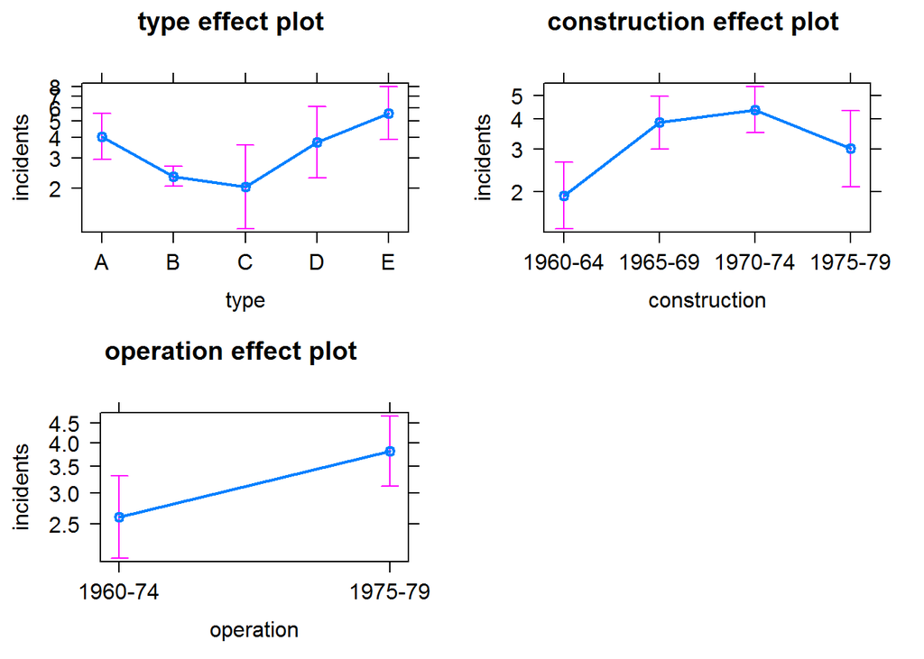

```r
library(effects)
plot(allEffects(m3))
```

**Sol: Per poc, pero aquest model amb 3 variables no s’ajusta prou be**

# Comparativa de models

```r
anova(m2cd,m3,test="Chisq")
```

```
## Analysis of Deviance Table
##
## Model 1: incidents ~ construction + operation
## Model 2: incidents ~ type + construction + operation
##   Resid. Df Resid. Dev Df Deviance  Pr(>Chi)
## 1        29     62.536
## 2        25     38.963  4   23.573 9.725e-05 ***
## ---
## Signif. codes:  0 '***' 0.001 '**' 0.01 '*' 0.05 '.' 0.1 ' ' 1
```

```r
anova(m2ad,m3,test="Chisq")
```

```
## Analysis of Deviance Table
##
## Model 1: incidents ~ type + operation
## Model 2: incidents ~ type + construction + operation
##   Resid. Df Resid. Dev Df Deviance  Pr(>Chi)
## 1        28     70.364
## 2        25     38.963  3   31.401 6.998e-07 ***
## ---
## Signif. codes:  0 '***' 0.001 '**' 0.01 '*' 0.05 '.' 0.1 ' ' 1
```

```r
anova(m2ac,m3,test="Chisq")
```

```
## Analysis of Deviance Table
##
## Model 1: incidents ~ type + construction
## Model 2: incidents ~ type + construction + operation
##   Resid. Df Resid. Dev Df Deviance Pr(>Chi)
## 1        26     49.591
## 2        25     38.963  1   10.628 0.001114 **
## ---
## Signif. codes:  0 '***' 0.001 '**' 0.01 '*' 0.05 '.' 0.1 ' ' 1
```

**Sol: Les 3 variables han d’estar en el model –> p-valors<0.05**

# Interpretacio de model nul i model amb 3 variables

```r
co0 <- c(coef(m0),confint(m0))
round(exp(co0),4)       # mensual
```

```
## (Intercept)       2.5 %      97.5 %
##      0.0022      0.0020      0.0024
```

```r
round(exp(-exp(co0)),4) # Probabilitat de 0 incidencies --> P(X=0) = exp(-lambda)
```

```
## (Intercept)       2.5 %      97.5 %
##      0.9978      0.9980      0.9976
```

```r
co3 <- cbind(coef(m3),confint(m3))
round(exp(co3),4)       # mensual
```

```
##                             2.5 % 97.5 %
## (Intercept)         0.0017 0.0011 0.0025
## typeB               0.5800 0.4136 0.8312
## typeC               0.5022 0.2521 0.9269
## typeD               0.9284 0.5118 1.6110
## typeE               1.3779 0.8622 2.1812
## construction1965-69 2.0054 1.5011 2.7016
## construction1970-74 2.2647 1.6261 3.1672
## construction1975-79 1.5604 0.9793 2.4487
## operation1975-79    1.4679 1.1651 1.8529
```

**Sol: La taxa mitjana global d’accidents mensual per vaixell es 0.0022 (IC95%: 0.0020 a 0.0024). La taxa mitjana en el grup amb totes les categories de referencia es 0.0017 (IC95%: 0.0011 a 0.0025). Els de type E tenen una taxa mitjana mensual d’incidencies 1.38 vegades (IC95%: 0.86 a 2.18) superior als del tipus A. La probabilitat global de no tenir cap incidencia en un mes es 0.9978 (IC95%: 0.9976 a 0.9980). No obstant cap d’aquests models ha quedat validat**

(Intercept) 0.0017 taxa base.

# Interaccions

### 1 interaccio

```r
m3cd <- glm(incidents ~ type + construction*operation, family = poisson, data = df, offset = log(service))
summary(m3cd)
```

```
##
## Call:
## glm(formula = incidents ~ type + construction * operation, family = poisson,
##     data = df, offset = log(service))
##
## Deviance Residuals:
##     Min       1Q   Median       3Q      Max
## -1.6573  -0.8118  -0.3406   0.3750   2.7204
##
## Coefficients: (1 not defined because of singularities)
##                                      Estimate Std. Error z value Pr(>|z|)
## (Intercept)                          -6.51149    0.23643 -27.541  < 2e-16
## typeB                                -0.54740    0.17766  -3.081  0.00206
## typeC                                -0.69058    0.32906  -2.099  0.03585
## typeD                                -0.07456    0.29066  -0.257  0.79754
## typeE                                 0.31627    0.23578   1.341  0.17978
## construction1965-69                   0.85873    0.19992   4.295 1.74e-05
## construction1970-74                   0.97060    0.24701   3.929 8.52e-05
## construction1975-79                   0.27334    0.26082   1.048  0.29464
## operation1975-79                      0.66576    0.24153   2.756  0.00584
## construction1965-69:operation1975-79 -0.38504    0.29739  -1.295  0.19541
## construction1970-74:operation1975-79 -0.33885    0.31963  -1.060  0.28908
## construction1975-79:operation1975-79       NA         NA      NA       NA
##
## (Intercept)                          ***
## typeB                                **
## typeC                                *
## typeD
## typeE
## construction1965-69                  ***
## construction1970-74                  ***
## construction1975-79
## operation1975-79                     **
## construction1965-69:operation1975-79
## construction1970-74:operation1975-79
## construction1975-79:operation1975-79
## ---
## Signif. codes:  0 '***' 0.001 '**' 0.01 '*' 0.05 '.' 0.1 ' ' 1
##
## (Dispersion parameter for poisson family taken to be 1)
##
##     Null deviance: 146.328  on 33  degrees of freedom
## Residual deviance:  37.196  on 23  degrees of freedom
## AIC: 157.06
##
## Number of Fisher Scoring iterations: 5
```

```r
cat('Punt critic per la devianza:',qchisq(0.95,m3cd$df.res),'\n')
```

```
## Punt critic per la devianza: 35.17246
```

```r
m3ad <- glm(incidents ~ type*operation + construction , family = poisson, data = df, offset = log(service))
summary(m3ad)
```

```
##
## Call:
## glm(formula = incidents ~ type * operation + construction, family = poisson,
##     data = df, offset = log(service))
##
## Deviance Residuals:
##     Min       1Q   Median       3Q      Max
## -2.1973  -0.7560  -0.4843   0.7316   2.2410
##
## Coefficients:
##                         Estimate Std. Error z value Pr(>|z|)
## (Intercept)            -6.452645   0.363412 -17.756  < 2e-16 ***
## typeB                  -0.530945   0.353730  -1.501   0.1334
## typeC                  -0.012052   0.505405  -0.024   0.9810
## typeD                  -0.237882   0.782016  -0.304   0.7610
## typeE                   0.600764   0.440979   1.362   0.1731
## operation1975-79        0.458861   0.379742   1.208   0.2269
## construction1965-69     0.685420   0.150385   4.558 5.17e-06 ***
## construction1970-74     0.813061   0.169744   4.790 1.67e-06 ***
## construction1975-79     0.425511   0.233657   1.821   0.0686 .
## typeB:operation1975-79  0.001516   0.399056   0.004   0.9970
## typeC:operation1975-79 -1.195376   0.697608  -1.714   0.0866 .
## typeD:operation1975-79  0.183720   0.842847   0.218   0.8274
## typeE:operation1975-79 -0.411848   0.524789  -0.785   0.4326
## ---
## Signif. codes:  0 '***' 0.001 '**' 0.01 '*' 0.05 '.' 0.1 ' ' 1
##
## (Dispersion parameter for poisson family taken to be 1)
##
##     Null deviance: 146.328  on 33  degrees of freedom
## Residual deviance:  33.918  on 21  degrees of freedom
## AIC: 157.78
##
## Number of Fisher Scoring iterations: 5
```

```r
cat('Punt critic per la devianza:',qchisq(0.95,m3ad$df.res),'\n')
```

```
## Punt critic per la devianza: 32.67057
```

```r
m3ac <- glm(incidents ~ type*construction + operation, family = poisson, data = df, offset = log(service))
summary(m3ac)
```

```
##
## Call:
## glm(formula = incidents ~ type * construction + operation, family = poisson,
##     data = df, offset = log(service))
##
## Deviance Residuals:
##      Min        1Q    Median        3Q       Max
## -1.99643  -0.12195  -0.00008   0.13849   2.53827
##
## Coefficients: (1 not defined because of singularities)
##                             Estimate Std. Error z value Pr(>|z|)
## (Intercept)                 -23.9891  6625.5246  -0.004  0.99711
## typeB                        17.0506  6625.5246   0.003  0.99795
## typeC                        17.0863  6625.5247   0.003  0.99794
## typeD                        -0.5962  9331.1045   0.000  0.99995
## typeE                        -1.0569     1.0445  -1.012  0.31158
## construction1965-69          18.0324  6625.5247   0.003  0.99783
## construction1970-74          18.3969  6625.5247   0.003  0.99778
## construction1975-79          18.2860  6625.5247   0.003  0.99780
## operation1975-79              0.3850     0.1186   3.246  0.00117 **
## typeB:construction1965-69   -17.3620  6625.5247  -0.003  0.99791
## typeC:construction1965-69   -18.6108  6625.5248  -0.003  0.99776
## typeD:construction1965-69   -18.4024 11467.2827  -0.002  0.99872
## typeE:construction1965-69     2.3863     1.1426   2.089  0.03675 *
## typeB:construction1970-74   -17.6110  6625.5247  -0.003  0.99788
## typeC:construction1970-74   -17.6160  6625.5247  -0.003  0.99788
## typeD:construction1970-74     1.0922  9331.1045   0.000  0.99991
## typeE:construction1970-74     1.1083     1.0915   1.015  0.30992
## typeB:construction1975-79   -17.7124  6625.5247  -0.003  0.99787
## typeC:construction1975-79   -17.3813  6625.5248  -0.003  0.99791
## typeD:construction1975-79    -0.3254  9331.1045   0.000  0.99997
## typeE:construction1975-79         NA         NA      NA       NA
## ---
## Signif. codes:  0 '***' 0.001 '**' 0.01 '*' 0.05 '.' 0.1 ' ' 1
##
## (Dispersion parameter for poisson family taken to be 1)
##
##     Null deviance: 146.328  on 33  degrees of freedom
## Residual deviance:  14.746  on 14  degrees of freedom
## AIC: 152.61
##
## Number of Fisher Scoring iterations: 17
```

```r
cat('Punt critic per la devianza:',qchisq(0.95,m3ac$df.res),'\n')
```

```
## Punt critic per la devianza: 23.68479
```

```r
anova(m3,m3cd,test='Chisq')
```

```
## Analysis of Deviance Table
##
## Model 1: incidents ~ type + construction + operation
## Model 2: incidents ~ type + construction * operation
##   Resid. Df Resid. Dev Df Deviance Pr(>Chi)
## 1        25     38.963
## 2        23     37.196  2   1.7667   0.4134
```

```r
anova(m3,m3ad,test='Chisq')
```

```
## Analysis of Deviance Table
##
## Model 1: incidents ~ type + construction + operation
## Model 2: incidents ~ type * operation + construction
##   Resid. Df Resid. Dev Df Deviance Pr(>Chi)
## 1        25     38.963
## 2        21     33.918  4   5.0451   0.2827
```

```r
anova(m3,m3ac,test='Chisq')
```

```
## Analysis of Deviance Table
##
## Model 1: incidents ~ type + construction + operation
## Model 2: incidents ~ type * construction + operation
##   Resid. Df Resid. Dev Df Deviance Pr(>Chi)
## 1        25     38.963
## 2        14     14.746 11   24.216  0.01185 *
## ---
## Signif. codes:  0 '***' 0.001 '**' 0.01 '*' 0.05 '.' 0.1 ' ' 1
```

**Sol: surt significativa la interaccio type i construction. No obstant, en aquest model, no s’estimen be els errors estandards**. En el summary veiem molts pvalors de 0.99, al tenir massa paràmetres (12+intercept), els zvalues són tan petits que quasi no veiemem la significació. Està sobreparametritzats i no podem estimar be els coeficients (dona una mala estimació i inferència dels coeficients del model).

### 2 interaccions

```r
m3acad <- glm(incidents ~ type*(construction + operation), family = poisson, data = df, offset = log(service))
summary(m3acad)
```

```
##
## Call:
## glm(formula = incidents ~ type * (construction + operation),
##     family = poisson, data = df, offset = log(service))
##
## Deviance Residuals:
##      Min        1Q    Median        3Q       Max
## -1.25282  -0.12709  -0.00004   0.06164   1.22581
##
## Coefficients: (1 not defined because of singularities)
##                             Estimate Std. Error z value Pr(>|z|)
## (Intercept)                 -23.9456  6599.7648  -0.004   0.9971
## typeB                        16.9814  6599.7648   0.003   0.9979
## typeC                        17.4280  6599.7648   0.003   0.9979
## typeD                        -0.6790  9333.4229   0.000   0.9999
## typeE                        -1.1817     1.1832  -0.999   0.3179
## construction1965-69          18.0397  6599.7648   0.003   0.9978
## construction1970-74          18.4192  6599.7648   0.003   0.9978
## construction1975-79          18.3293  6599.7648   0.003   0.9978
## operation1975-79              0.2982     0.4009   0.744   0.4570
## typeB:construction1965-69   -17.3798  6599.7648  -0.003   0.9979
## typeC:construction1965-69   -18.4251  6599.7649  -0.003   0.9978
## typeD:construction1965-69   -18.4093 11468.1651  -0.002   0.9987
## typeE:construction1965-69     2.4432     1.1738   2.081   0.0374 *
## typeB:construction1970-74   -17.6591  6599.7648  -0.003   0.9979
## typeC:construction1970-74   -17.0665  6599.7648  -0.003   0.9979
## typeD:construction1970-74     1.0435  9333.4229   0.000   0.9999
## typeE:construction1970-74     1.1394     1.1007   1.035   0.3006
## typeB:construction1975-79   -17.7998  6599.7648  -0.003   0.9978
## typeC:construction1975-79   -16.2755  6599.7649  -0.002   0.9980
## typeD:construction1975-79    -0.4075  9333.4229   0.000   1.0000
## typeE:construction1975-79         NA         NA      NA       NA
## typeB:operation1975-79        0.1567     0.4233   0.370   0.7113
## typeC:operation1975-79       -1.4475     0.7638  -1.895   0.0581 .
## typeD:operation1975-79        0.1649     0.8670   0.190   0.8491
## typeE:operation1975-79        0.1248     0.5559   0.225   0.8223
## ---
## Signif. codes:  0 '***' 0.001 '**' 0.01 '*' 0.05 '.' 0.1 ' ' 1
##
## (Dispersion parameter for poisson family taken to be 1)
##
##     Null deviance: 146.3283  on 33  degrees of freedom
## Residual deviance:   8.6803  on 10  degrees of freedom
## AIC: 154.55
##
## Number of Fisher Scoring iterations: 17
```

```r
cat('Punt critic per la devianza:',qchisq(0.95,m3acad$df.res),'\n')
```

```
## Punt critic per la devianza: 18.30704
```

```r
m3accd <- glm(incidents ~ construction*(type + operation), family = poisson, data = df, offset = log(service))
summary(m3accd)
```

```
##
## Call:
## glm(formula = incidents ~ construction * (type + operation),
##     family = poisson, data = df, offset = log(service))
##
## Deviance Residuals:
##      Min        1Q    Median        3Q       Max
## -1.95502  -0.03687  -0.00009   0.03840   2.42282
##
## Coefficients: (2 not defined because of singularities)
##                                        Estimate Std. Error z value
## (Intercept)                            -24.1298  6665.1684  -0.004
## construction1965-69                     18.2219  6665.1684   0.003
## construction1970-74                     18.6036  6665.1684   0.003
## construction1975-79                     18.1446  6665.1684   0.003
## typeB                                   17.0804  6665.1684   0.003
## typeC                                   17.1022  6665.1684   0.003
## typeD                                   -0.5961  9414.1357   0.000
## typeE                                   -1.0569     1.0445  -1.012
## operation1975-79                         0.6670     0.2416   2.761
## construction1965-69:typeB              -17.3987  6665.1684  -0.003
## construction1970-74:typeB              -17.6437  6665.1684  -0.003
## construction1975-79:typeB              -17.7421  6665.1684  -0.003
## construction1965-69:typeC              -18.6298  6665.1685  -0.003
## construction1970-74:typeC              -17.6301  6665.1684  -0.003
## construction1975-79:typeC              -17.3972  6665.1685  -0.003
## construction1965-69:typeD              -18.4095 11532.1833  -0.002
## construction1970-74:typeD                1.0983  9414.1357   0.000
## construction1975-79:typeD               -0.3256  9414.1357   0.000
## construction1965-69:typeE                2.3741     1.1427   2.078
## construction1970-74:typeE                1.1054     1.0915   1.013
## construction1975-79:typeE                    NA         NA      NA
## construction1965-69:operation1975-79    -0.3655     0.2976  -1.228
## construction1970-74:operation1975-79    -0.3692     0.3200  -1.154
## construction1975-79:operation1975-79         NA         NA      NA
##                                      Pr(>|z|)
## (Intercept)                           0.99711
## construction1965-69                   0.99782
## construction1970-74                   0.99777
## construction1975-79                   0.99783
```

[output cut: 15 more lines]

```
## construction1970-74:typeE             0.31118
## construction1975-79:typeE                  NA
## construction1965-69:operation1975-79  0.21935
## construction1970-74:operation1975-79  0.24860
## construction1975-79:operation1975-79       NA
## ---
## Signif. codes:  0 '***' 0.001 '**' 0.01 '*' 0.05 '.' 0.1 ' ' 1
##
## (Dispersion parameter for poisson family taken to be 1)
##
##     Null deviance: 146.328  on 33  degrees of freedom
## Residual deviance:  13.005  on 12  degrees of freedom
## AIC: 154.87
##
## Number of Fisher Scoring iterations: 17
```

```r
cat('Punt critic per la devianza:',qchisq(0.95,m3accd$df.res),'\n')
```

```
## Punt critic per la devianza: 21.02607
```

```r
anova(m3ac,m3acad,test='Chisq')
```

```
## Analysis of Deviance Table
##
## Model 1: incidents ~ type * construction + operation
## Model 2: incidents ~ type * (construction + operation)
##   Resid. Df Resid. Dev Df Deviance Pr(>Chi)
## 1        14    14.7464
## 2        10     8.6803  4   6.0661   0.1943
```

```r
anova(m3ac,m3accd,test='Chisq')
```

```
## Analysis of Deviance Table
##
## Model 1: incidents ~ type * construction + operation
## Model 2: incidents ~ construction * (type + operation)
##   Resid. Df Resid. Dev Df Deviance Pr(>Chi)
## 1        14     14.746
## 2        12     13.005  2   1.7416   0.4186
```

Quan ens surt NA, és perquè són condicions que no es donen.

**Sol: cap interaccio mes**

# Seleccio de variables per stepwise partint del model saturat

```r
m4 <- glm(incidents ~ construction*type*operation, family = poisson, data = df, offset = log(service))
summary(m4)
```

```
##
## Call:
## glm(formula = incidents ~ construction * type * operation, family = poisson,
##     data = df, offset = log(service))
##
## Deviance Residuals:
##        1         2         3         4         5         6         8
## -0.00001  -0.00001   0.00000   0.00000   0.00000   0.00000   0.00000
##        9        10        11        12        13        14        16
##  0.00000   0.00000   0.00000   0.00000   0.00000   0.00000   0.00000
##       17        18        19        20        21        22        24
##  0.00000   0.00000  -0.00001   0.00000   0.00000   0.00000   0.00000
##       25        26        27        28        29        30        32
## -0.00001  -0.00001  -0.00001  -0.00001   0.00000   0.00000   0.00000
##       33        35        36        37        38        40
## -0.39156   0.00000   0.00000   0.00000   0.00000   0.07871
##
## Coefficients: (7 not defined because of singularities)
##                                              Estimate Std. Error z value
## (Intercept)                                -2.815e+01  6.965e+04   0.000
## construction1965-69                         2.225e+01  6.965e+04   0.000
## construction1970-74                         2.262e+01  6.965e+04   0.000
## construction1975-79                         2.213e+01  6.965e+04   0.000
## typeB                                       2.110e+01  6.965e+04   0.000
## typeC                                       2.107e+01  6.965e+04   0.000
## typeD                                      -6.813e-01  9.851e+04   0.000
## typeE                                      -1.005e+00  1.264e+00  -0.796
## operation1975-79                            7.011e-01  9.851e+04   0.000
## construction1965-69:typeB                  -2.140e+01  6.965e+04   0.000
## construction1970-74:typeB                  -2.195e+01  6.965e+04   0.000
## construction1975-79:typeB                  -2.172e+01  6.965e+04   0.000
## construction1965-69:typeC                  -4.514e+01  9.851e+04   0.000
## construction1970-74:typeC                  -2.042e+01  6.965e+04   0.000
## construction1975-79:typeC                  -2.143e+01  6.965e+04   0.000
## construction1965-69:typeD                  -2.238e+01  1.206e+05   0.000
## construction1970-74:typeD                   1.049e+00  9.851e+04   0.000
## construction1975-79:typeD                  -4.108e-01  9.851e+04   0.000
## construction1965-69:typeE                   2.180e+00  1.440e+00   1.515
## construction1970-74:typeE                   1.091e+00  1.109e+00   0.984
## construction1975-79:typeE                          NA         NA      NA
```

[output cut: 53 more lines]

```
## construction1975-79:typeC:operation1975-79       NA
## construction1965-69:typeD:operation1975-79    1.000
## construction1970-74:typeD:operation1975-79    1.000
## construction1975-79:typeD:operation1975-79       NA
## construction1965-69:typeE:operation1975-79    0.762
## construction1970-74:typeE:operation1975-79       NA
## construction1975-79:typeE:operation1975-79       NA
##
## (Dispersion parameter for poisson family taken to be 1)
##
##     Null deviance: 146.32834  on 33  degrees of freedom
## Residual deviance:   0.15952  on  1  degrees of freedom
## AIC: 164.03
##
## Number of Fisher Scoring iterations: 21
```

```r
m4.aic <- step(m4)              # AIC
```

```
## Start:  AIC=164.03
## incidents ~ construction * type * operation
##
##                               Df Deviance    AIC
## - construction:type:operation  7   7.0160 156.88
## <none>                             0.1595 164.03
##
## Step:  AIC=156.88
## incidents ~ construction + type + operation + construction:type +
##     construction:operation + type:operation
##
##                          Df Deviance    AIC
## - construction:operation  2    8.680 154.55
## - type:operation          4   13.005 154.87
## <none>                         7.016 156.88
## - construction:type      11   32.400 160.27
##
## Step:  AIC=154.55
## incidents ~ construction + type + operation + construction:type +
##     type:operation
##
##                     Df Deviance    AIC
## - type:operation     4   14.746 152.61
## <none>                    8.680 154.55
## - construction:type 11   33.918 157.78
##
## Step:  AIC=152.61
## incidents ~ construction + type + operation + construction:type
##
##                     Df Deviance    AIC
## <none>                   14.746 152.61
## - construction:type 11   38.963 154.83
## - operation          1   25.368 161.23
```

```r
m4.bic <- step(m4, k=log(34))   # BIC
```

```
## Start:  AIC=214.4
## incidents ~ construction * type * operation
##
##                               Df Deviance    AIC
## - construction:type:operation  7   7.0160 196.57
## <none>                             0.1595 214.40
##
## Step:  AIC=196.57
## incidents ~ construction + type + operation + construction:type +
##     construction:operation + type:operation
##
##                          Df Deviance    AIC
## - construction:type      11   32.400 183.16
## - type:operation          4   13.005 188.45
## - construction:operation  2    8.680 191.18
## <none>                         7.016 196.57
##
## Step:  AIC=183.16
## incidents ~ construction + type + operation + construction:operation +
##     type:operation
##
##                          Df Deviance    AIC
## - type:operation          4   37.196 173.85
## - construction:operation  2   33.918 177.63
## <none>                        32.400 183.16
##
## Step:  AIC=173.85
## incidents ~ construction + type + operation + construction:operation
##
##                          Df Deviance    AIC
## - construction:operation  2   38.963 168.57
## <none>                        37.196 173.85
## - type                    4   60.797 183.35
##
## Step:  AIC=168.57
## incidents ~ construction + type + operation
##
##                Df Deviance    AIC
## <none>              38.963 168.57
## - operation     1   49.591 175.67
## - type          4   62.536 178.03
## - construction  3   70.364 189.39
```

```r
summary(m4.aic)
```

```
##
## Call:
## glm(formula = incidents ~ construction + type + operation + construction:type,
##     family = poisson, data = df, offset = log(service))
##
## Deviance Residuals:
##      Min        1Q    Median        3Q       Max
## -1.99643  -0.12195  -0.00008   0.13849   2.53827
##
## Coefficients: (1 not defined because of singularities)
##                             Estimate Std. Error z value Pr(>|z|)
## (Intercept)                 -23.9891  6625.5245  -0.004  0.99711
## construction1965-69          18.0324  6625.5245   0.003  0.99783
## construction1970-74          18.3969  6625.5245   0.003  0.99778
## construction1975-79          18.2860  6625.5245   0.003  0.99780
## typeB                        17.0506  6625.5245   0.003  0.99795
## typeC                        17.0863  6625.5245   0.003  0.99794
## typeD                        -0.5962  9331.1043   0.000  0.99995
## typeE                        -1.0569     1.0445  -1.012  0.31158
## operation1975-79              0.3850     0.1186   3.246  0.00117 **
## construction1965-69:typeB   -17.3620  6625.5245  -0.003  0.99791
## construction1970-74:typeB   -17.6110  6625.5245  -0.003  0.99788
## construction1975-79:typeB   -17.7124  6625.5245  -0.003  0.99787
## construction1965-69:typeC   -18.6108  6625.5246  -0.003  0.99776
## construction1970-74:typeC   -17.6160  6625.5245  -0.003  0.99788
## construction1975-79:typeC   -17.3813  6625.5246  -0.003  0.99791
## construction1965-69:typeD   -18.4024 11467.2826  -0.002  0.99872
## construction1970-74:typeD     1.0922  9331.1043   0.000  0.99991
## construction1975-79:typeD    -0.3254  9331.1043   0.000  0.99997
## construction1965-69:typeE     2.3863     1.1426   2.089  0.03675 *
## construction1970-74:typeE     1.1083     1.0915   1.015  0.30992
## construction1975-79:typeE         NA         NA      NA       NA
## ---
## Signif. codes:  0 '***' 0.001 '**' 0.01 '*' 0.05 '.' 0.1 ' ' 1
##
## (Dispersion parameter for poisson family taken to be 1)
##
##     Null deviance: 146.328  on 33  degrees of freedom
## Residual deviance:  14.746  on 14  degrees of freedom
## AIC: 152.61
##
## Number of Fisher Scoring iterations: 17
```

```r
summary(m4.bic)
```

```
##
## Call:
## glm(formula = incidents ~ construction + type + operation, family = poisson,
##     data = df, offset = log(service))
##
## Deviance Residuals:
##     Min       1Q   Median       3Q      Max
## -1.6770  -0.8312  -0.4818   0.5277   2.7901
##
## Coefficients:
##                     Estimate Std. Error z value Pr(>|z|)
## (Intercept)         -6.40288    0.21752 -29.435  < 2e-16 ***
## construction1965-69  0.69585    0.14966   4.650 3.33e-06 ***
## construction1970-74  0.81746    0.16984   4.813 1.49e-06 ***
## construction1975-79  0.44497    0.23324   1.908  0.05642 .
## typeB               -0.54471    0.17761  -3.067  0.00216 **
## typeC               -0.68876    0.32903  -2.093  0.03632 *
## typeD               -0.07431    0.29056  -0.256  0.79815
## typeE                0.32053    0.23575   1.360  0.17396
## operation1975-79     0.38386    0.11826   3.246  0.00117 **
## ---
## Signif. codes:  0 '***' 0.001 '**' 0.01 '*' 0.05 '.' 0.1 ' ' 1
##
## (Dispersion parameter for poisson family taken to be 1)
##
##     Null deviance: 146.328  on 33  degrees of freedom
## Residual deviance:  38.963  on 25  degrees of freedom
## AIC: 154.83
##
## Number of Fisher Scoring iterations: 5
```

**Sol: amb AIC ens quedem la interaccio. Amb BIC, no. Decidim quedar-nos amb el model additiu resultant del BIC**

# Overdispersion

```r
dispersiontest(m3, trafo = 1)   # Lineal amb model additiu
```

```
##
##  Overdispersion test
##
## data:  m3
## z = 0.93429, p-value = 0.1751
## alternative hypothesis: true alpha is greater than 0
## sample estimates:
##     alpha
## 0.3179179
```

```r
dispersiontest(m3, trafo = 2)   # Quadratica amb model additiu
```

```
##
##  Overdispersion test
##
## data:  m3
## z = -0.6129, p-value = 0.73
## alternative hypothesis: true alpha is greater than 0
## sample estimates:
##      alpha
## -0.0111868
```

Alpha: 0.3179179 amb p-value = 0.1751. La quasi poisson no m’indica que hi hagi sobresidperssió.

alpha = -0.0111868 amb p-value = 0.73. LA BN tampoc m’indica que hi hagi sobredisperssió.

**Sol: No hi ha sobredispersio**

# Quasi-poisson

```r
# Additiu
m3.qp <- glm(incidents ~ type + construction + operation + offset(log(service)), family=quasipoisson, data = df)
summary(m3.qp)
```

```
##
## Call:
## glm(formula = incidents ~ type + construction + operation + offset(log(service)),
##     family = quasipoisson, data = df)
##
## Deviance Residuals:
##     Min       1Q   Median       3Q      Max
## -1.6770  -0.8312  -0.4818   0.5277   2.7901
##
## Coefficients:
##                     Estimate Std. Error t value Pr(>|t|)
## (Intercept)         -6.40288    0.28342 -22.591  < 2e-16 ***
## typeB               -0.54471    0.23142  -2.354  0.02675 *
## typeC               -0.68876    0.42871  -1.607  0.12070
## typeD               -0.07431    0.37858  -0.196  0.84598
## typeE                0.32053    0.30717   1.043  0.30671
## construction1965-69  0.69585    0.19499   3.569  0.00149 **
## construction1970-74  0.81746    0.22129   3.694  0.00108 **
## construction1975-79  0.44497    0.30390   1.464  0.15560
## operation1975-79     0.38386    0.15409   2.491  0.01973 *
## ---
## Signif. codes:  0 '***' 0.001 '**' 0.01 '*' 0.05 '.' 0.1 ' ' 1
##
## (Dispersion parameter for quasipoisson family taken to be 1.697675)
##
##     Null deviance: 146.328  on 33  degrees of freedom
## Residual deviance:  38.963  on 25  degrees of freedom
## AIC: NA
##
## Number of Fisher Scoring iterations: 5
```

```r
summary(m3)
```

```
##
## Call:
## glm(formula = incidents ~ type + construction + operation, family = poisson,
##     data = df, offset = log(service))
##
## Deviance Residuals:
##     Min       1Q   Median       3Q      Max
## -1.6770  -0.8312  -0.4818   0.5277   2.7901
##
## Coefficients:
##                     Estimate Std. Error z value Pr(>|z|)
## (Intercept)         -6.40288    0.21752 -29.435  < 2e-16 ***
## typeB               -0.54471    0.17761  -3.067  0.00216 **
## typeC               -0.68876    0.32903  -2.093  0.03632 *
## typeD               -0.07431    0.29056  -0.256  0.79815
## typeE                0.32053    0.23575   1.360  0.17396
## construction1965-69  0.69585    0.14966   4.650 3.33e-06 ***
## construction1970-74  0.81746    0.16984   4.813 1.49e-06 ***
## construction1975-79  0.44497    0.23324   1.908  0.05642 .
## operation1975-79     0.38386    0.11826   3.246  0.00117 **
## ---
## Signif. codes:  0 '***' 0.001 '**' 0.01 '*' 0.05 '.' 0.1 ' ' 1
##
## (Dispersion parameter for poisson family taken to be 1)
##
##     Null deviance: 146.328  on 33  degrees of freedom
## Residual deviance:  38.963  on 25  degrees of freedom
## AIC: 154.83
##
## Number of Fisher Scoring iterations: 5
```

Els coeficients son iguals lo únic que canvia són els errors estàndards (std.error), ha inflat els errors.

No ens podem creure aques model perquè al darrera no hi ha un model de probabilitat i no podem considerar el teorema central de limit etc etc. No podem fer inferència a partir d’aquest modle i per tant l’efectivitat d’aplicacions pràctiques no és adequada, ens la rebutjaran.

# Binomial negativa

```r
# Additiu
m3.nb <- glm.nb(incidents ~ type + construction + operation + offset(log(service)), data = df)
summary(m3.nb)
```

```
##
## Call:
## glm.nb(formula = incidents ~ type + construction + operation +
##     offset(log(service)), data = df, init.theta = 52521.06565,
##     link = log)
##
## Deviance Residuals:
##     Min       1Q   Median       3Q      Max
## -1.6770  -0.8312  -0.4818   0.5276   2.7900
##
## Coefficients:
##                     Estimate Std. Error z value Pr(>|z|)
## (Intercept)         -6.40286    0.21757 -29.429  < 2e-16 ***
## typeB               -0.54471    0.17764  -3.066  0.00217 **
## typeC               -0.68875    0.32905  -2.093  0.03634 *
## typeD               -0.07431    0.29058  -0.256  0.79816
## typeE                0.32057    0.23578   1.360  0.17395
## construction1965-69  0.69584    0.14971   4.648 3.35e-06 ***
## construction1970-74  0.81743    0.16988   4.812 1.50e-06 ***
## construction1975-79  0.44493    0.23328   1.907  0.05649 .
## operation1975-79     0.38387    0.11830   3.245  0.00117 **
## ---
## Signif. codes:  0 '***' 0.001 '**' 0.01 '*' 0.05 '.' 0.1 ' ' 1
##
## (Dispersion parameter for Negative Binomial(52521.07) family taken to be 1)
##
##     Null deviance: 146.247  on 33  degrees of freedom
## Residual deviance:  38.958  on 25  degrees of freedom
## AIC: 156.83
##
## Number of Fisher Scoring iterations: 1
##
##
##               Theta:  52521
##           Std. Err.:  565839
## Warning while fitting theta: iteration limit reached
##
##  2 x log-likelihood:  -136.832
```

```r
summary(m3)
```

```
##
## Call:
## glm(formula = incidents ~ type + construction + operation, family = poisson,
##     data = df, offset = log(service))
##
## Deviance Residuals:
##     Min       1Q   Median       3Q      Max
## -1.6770  -0.8312  -0.4818   0.5277   2.7901
##
## Coefficients:
##                     Estimate Std. Error z value Pr(>|z|)
## (Intercept)         -6.40288    0.21752 -29.435  < 2e-16 ***
## typeB               -0.54471    0.17761  -3.067  0.00216 **
## typeC               -0.68876    0.32903  -2.093  0.03632 *
## typeD               -0.07431    0.29056  -0.256  0.79815
## typeE                0.32053    0.23575   1.360  0.17396
## construction1965-69  0.69585    0.14966   4.650 3.33e-06 ***
## construction1970-74  0.81746    0.16984   4.813 1.49e-06 ***
## construction1975-79  0.44497    0.23324   1.908  0.05642 .
## operation1975-79     0.38386    0.11826   3.246  0.00117 **
## ---
## Signif. codes:  0 '***' 0.001 '**' 0.01 '*' 0.05 '.' 0.1 ' ' 1
##
## (Dispersion parameter for poisson family taken to be 1)
##
##     Null deviance: 146.328  on 33  degrees of freedom
## Residual deviance:  38.963  on 25  degrees of freedom
## AIC: 154.83
##
## Number of Fisher Scoring iterations: 5
```

Theta: 52521 molt gran, ja veuiem que probablement no hi hagi sobredisperssió.

**Sol: El model amb binomial negativa surt igual al de Poisson**. Degut a que theta és molt gran i no hi ha sobredisperssió.

# Validacio

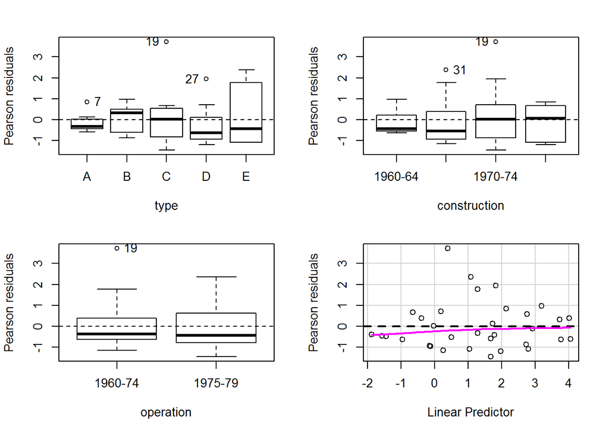

```r
residualPlots(m3.nb,label=row.names(df))
```

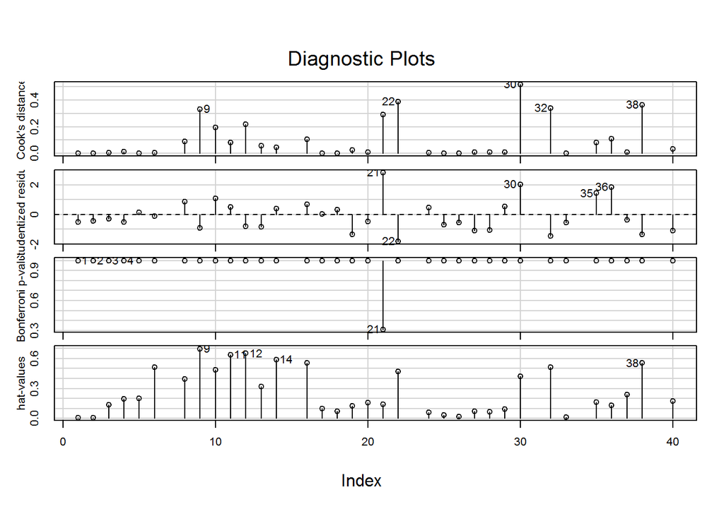

```r
influenceIndexPlot(m3.nb,id=list(vars=c("Cook", "hat"), n=5))
```

```r
par(mfrow=c(2,1))

## Residus grans
llista1 <- Boxplot(rstudent(m3.nb),label=row.names(df),main="RStudent")
df[llista1,]
```

```
##    type construction operation service incidents
## 21    C      1970-74   1960-74     783         6
```

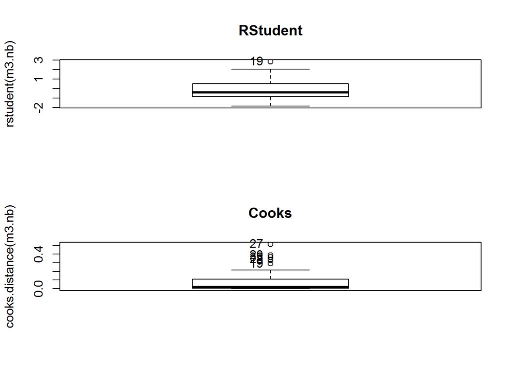

```r
## Dades influents
llista2 <- Boxplot(cooks.distance(m3.nb),label=row.names(df),main="Cooks")
```

```r
df[llista2,]
```

```
##    type construction operation service incidents
## 9     B      1960-64   1960-74   44882        39
## 21    C      1970-74   1960-74     783         6
## 22    C      1970-74   1975-79    1948         2
## 30    D      1970-74   1975-79    1208        11
## 32    D      1975-79   1975-79    2051         4
## 38    E      1970-74   1975-79    2161        12
```

```r
## Mitjana d'incidents per any
obsaccyear <- 12*df$incidents/df$service
summary(obsaccyear)
```

```
##    Min. 1st Qu.  Median    Mean 3rd Qu.    Max.
## 0.00000 0.01024 0.02387 0.03716 0.05080 0.19222
```

```r
## Estadístic de Pearson i Deviança
sum(resid(m3.nb, type="pearson")^2)
```

```
## [1] 42.43648
```

```r
m3.nb$dev
```

```
## [1] 38.9584
```

```r
m3.nb$df.residual
```

```
## [1] 25
```

```
## No Studentized residuals with Bonferonni p < 0.05
## Largest |rstudent|:
##    rstudent unadjusted p-value Bonferonni p
## 21 2.837998          0.0090886      0.30901
```

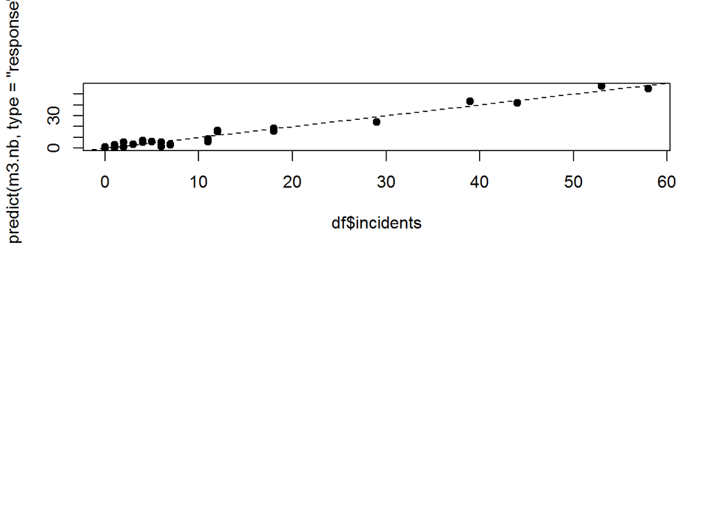

```r
## Observats vs. predits
plot(df$incidents,predict(m3.nb,type="response"),pch=19)
abline(0,1,lty=2)

## Outliers
outlierTest(m3.nb)
```

# Effects

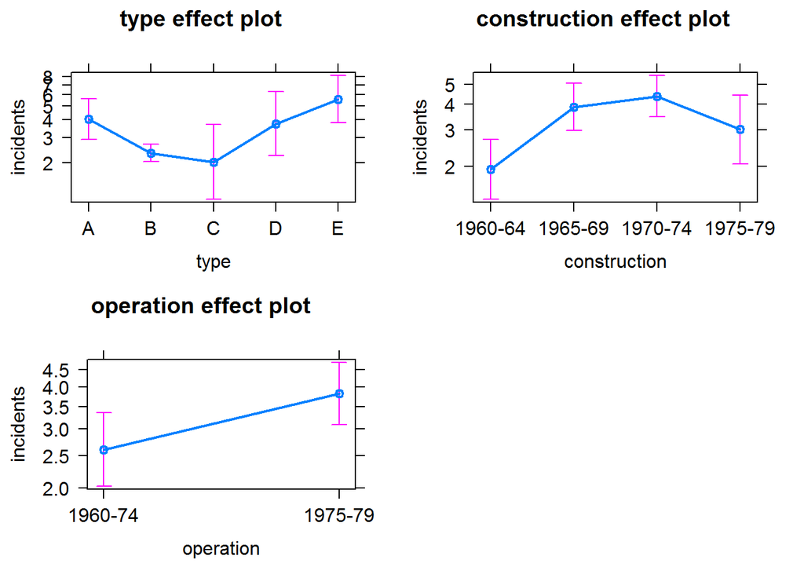

```r
par(mfrow=c(1,3))
plot(allEffects(m3.nb),ask=FALSE)
```